# HeatMap

orientation: To change the ‘horizontal’ or ‘vertical’ orientation of the color bar shrink: To change the size of the color bar extend: To change the end of the color bar like pointed or not. If you want pointed color bar both side then passes value ‘both’, for left ‘min’ , right ‘max’ and ‘neither’ for no pointed color bar. extendfrac: To adjust the extension of the color bar. The ‘auto’ value adjust pointer automatically, ‘False’ value for no pointer and float value will help to adjust color bar pointer according to you. ticks: To change the ticks of the color bar, Pass list or numpy array of ticks drawedges: To draw lines (edges) on the color bar. Pass bool ‘True’ value for lines.

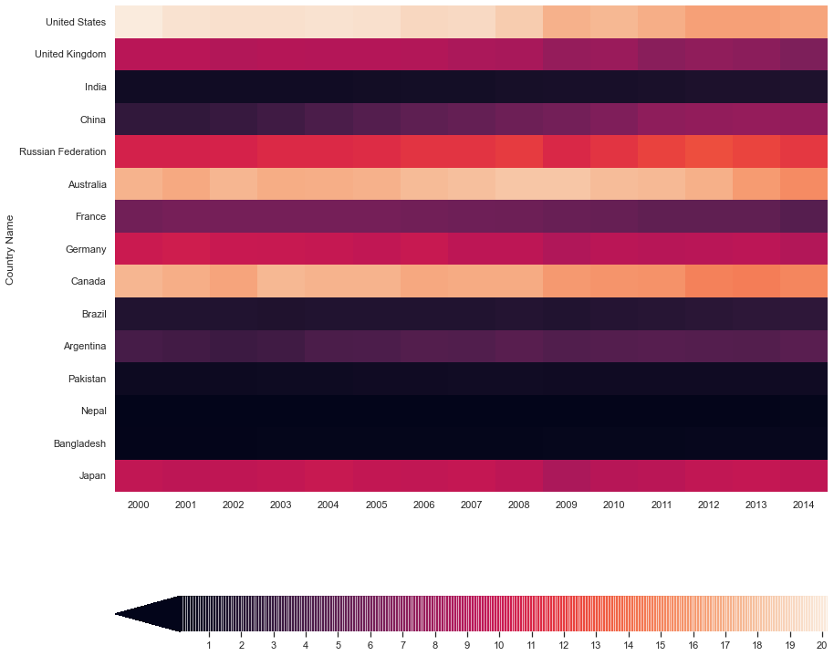

```python
# change style and format of color bar with cbar_kws parameter

plt.figure(figsize=(14,14))

cbar_kws = {"orientation":"horizontal",
            "shrink":1,
            'extend':'min',
            'extendfrac':0.1,
            "ticks":np.arange(0,22),
            "drawedges":True,
           }

sns.heatmap(globalWarming_df, cbar_kws=cbar_kws)
```

How to set each cell of the seaborn heatmap in a square format?

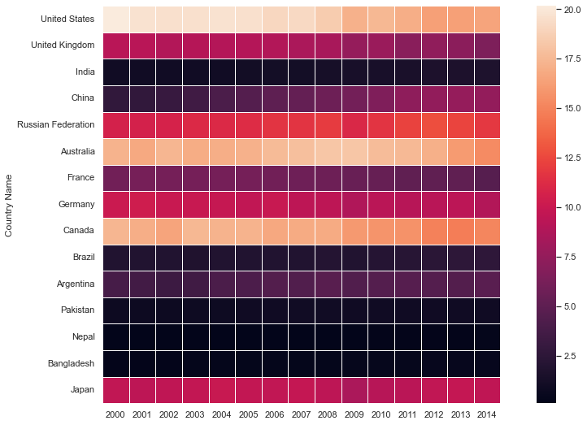

```python
# change the shape of each cell in a square with squre parameter

plt.figure(figsize=(16,9))

sns.heatmap(globalWarming_df, linewidths = 1, square= True)
```

Change x-axis labels or hide using sns.heatmap() xticklabels

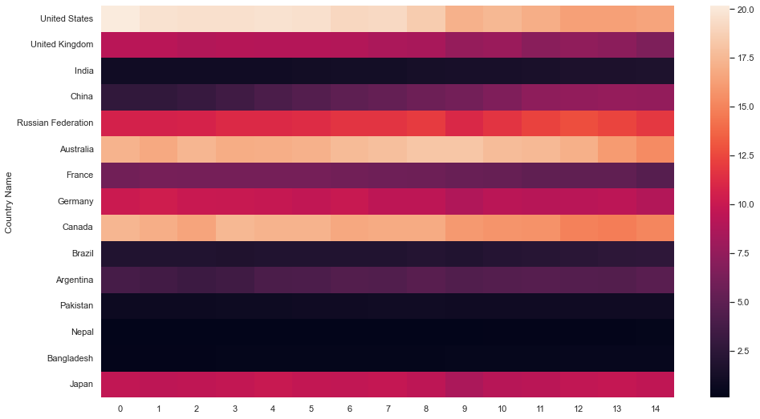

```python
# change x-axis labels using xticklabels parameter

plt.figure(figsize=(16,9))

sns.heatmap(globalWarming_df, xticklabels = np.arange(0,15))
```

Change y-axis labels or hide using sns.heatmap() yticklabels

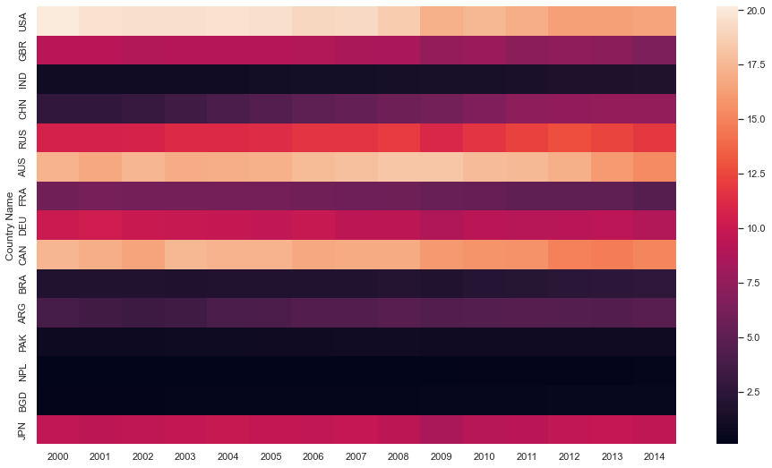

```python
# change y-axis labels using yticklabels parameter

plt.figure(figsize=(16,9))

country_code = ['USA', 'GBR', 'IND', 'CHN', 'RUS', 'AUS', 'FRA', 'DEU', 'CAN', 'BRA', 'ARG', 'PAK', 'NPL', 'BGD', 'JPN']

sns.heatmap(globalWarming_df, yticklabels = country_code)
```

Heatmap without xticklabels, yticklabels and color bar – meaningless heatmap

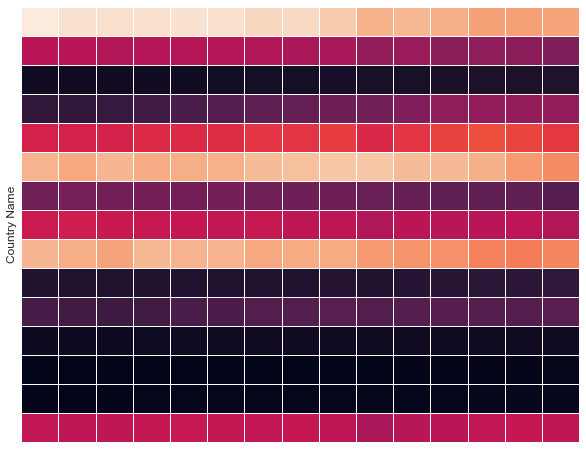

```python
# create square box

plt.figure(figsize=(10,8))

sns.heatmap(globalWarming_df, xticklabels = False, yticklabels = False, cbar=False, linecolor="w", linewidths=1)
```

Seaborn heatmap subplots – create multiple heatmaps

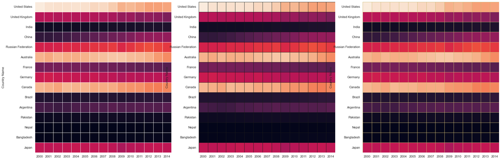

```python
# multiple heatmaps using subplots

plt.figure(figsize=(30,10))

plt.subplot(1,3,1) # first heatmap
sns.heatmap(globalWarming_df,  cbar=False, linecolor="w", linewidths=1)

plt.subplot(1,3,2) # second heatmap
sns.heatmap(globalWarming_df,  cbar=False, linecolor="k", linewidths=1)

plt.subplot(1,3,3) # third heatmap
sns.heatmap(globalWarming_df,  cbar=False, linecolor="y", linewidths=1)
```

Set seaborn heatmap title, x-axis, y-axis label, font size with ax (Axes) parameter

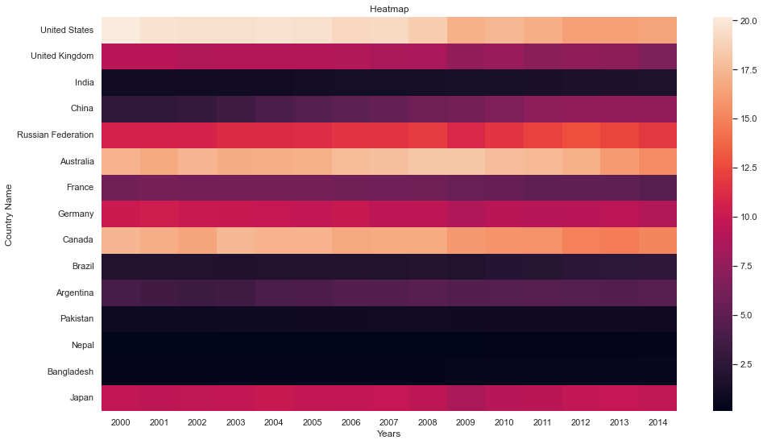

```python
 #set seaborn heatmap title, x-axis, y-axis label and font size

plt.figure(figsize=(16,9))

ax = sns.heatmap(globalWarming_df)

ax.set(title="Heatmap",
      xlabel="Years",
      ylabel="Country Name",)

sns.set(font_scale=2) # set fontsize 2
```

Seaborn heatmap keyword arguments (kwargs)

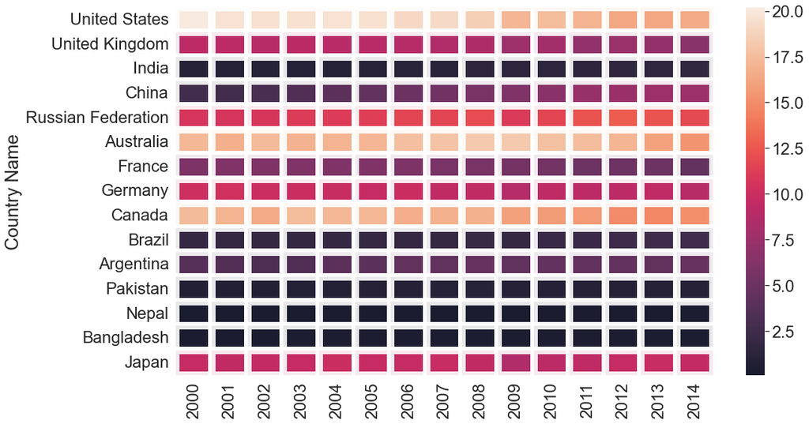

```python
# Heatmap with keyword arguments (kwargs) parameter

plt.figure(figsize = (16,9))

kwargs = {'alpha':.9,'linewidth':10, 'linestyle':'--', 'rasterized':False, 'edgecolor':'w',  "capstyle":'projecting',}

ax = sns.heatmap(globalWarming_df,**kwargs)
```

How to create a seaborn heatmap using correlation matrix?

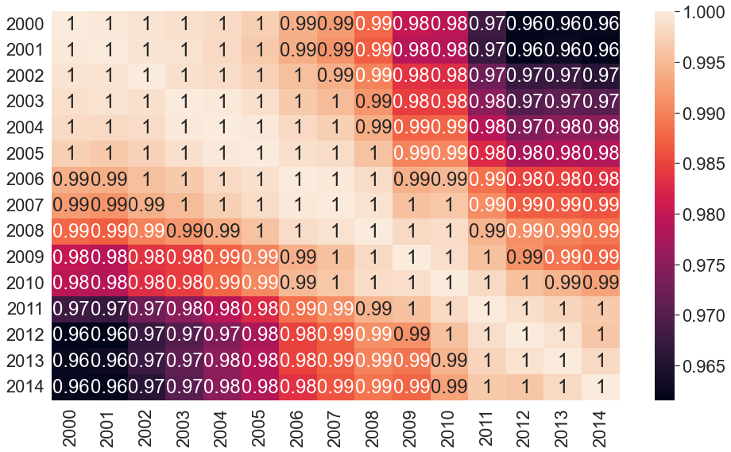

```python
# sns heatmap correlation

plt.figure(figsize=(16,9))

sns.heatmap(globalWarming_df.corr(), annot = True)
```

Upper triangle seaborn heatmap with mask

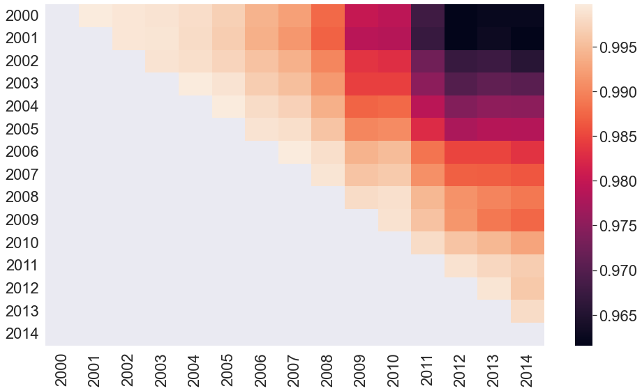

```python
# Upper triangle heatmap

plt.figure(figsize=(16,9))

corr_mx = globalWarming_df.corr() # correlation matrix

matrix = np.tril(corr_mx) # take lower correlation matrix

sns.heatmap(corr_mx, mask=matrix)
```

Lower triangle seaborn heatmap with mask

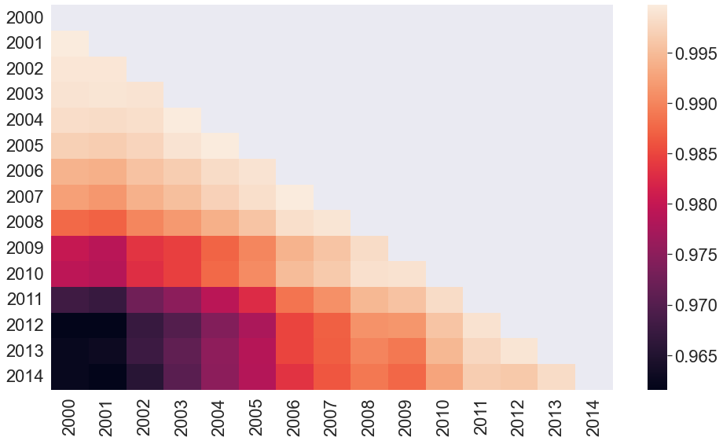

```python
# Lower triangle heatmap

plt.figure(figsize=(16,9))

corr_mx = globalWarming_df.corr() # correlation matrix

matrix = np.triu(corr_mx) # take upper correlation matrix

sns.heatmap(corr_mx, mask=matrix)
```

Seaborn heatmap examples for easy to use in the projects

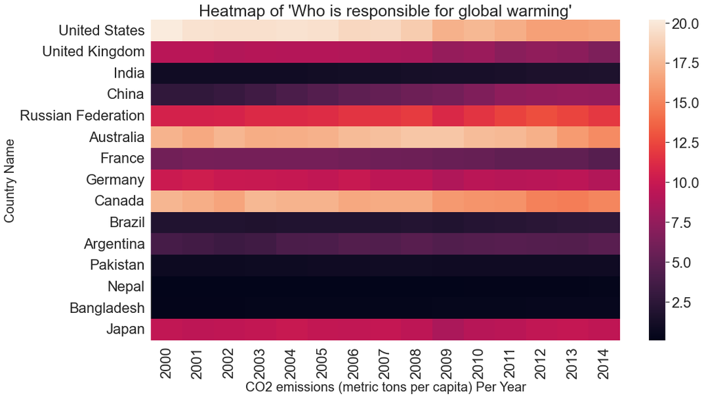

```python
# import libraries
import seaborn as sns # for data visualization
import matplotlib.pyplot as plt # for data visualization
import pandas as pd # for data analysis

# load dataset and create DataFrame ready to create heatmap
globalWarming_df = pd.read_csv("Who_is_responsible_for_global_warming.csv")
globalWarming_df = globalWarming_df.drop(columns=['Country Code', 'Indicator Name', 'Indicator Code'], axis=1).set_index('Country Name')

# set heatmap size
plt.figure(figsize= (16,9))

# create heatmap seaborn
sns.heatmap(globalWarming_df)

plt.title("Heatmap of 'Who is responsible for global warming'", fontsize = 25)
plt.xlabel("CO2 emissions (metric tons per capita) Per Year", fontsize = 20)
plt.ylabel("Country Name", fontsize = 20)
plt.show()
```

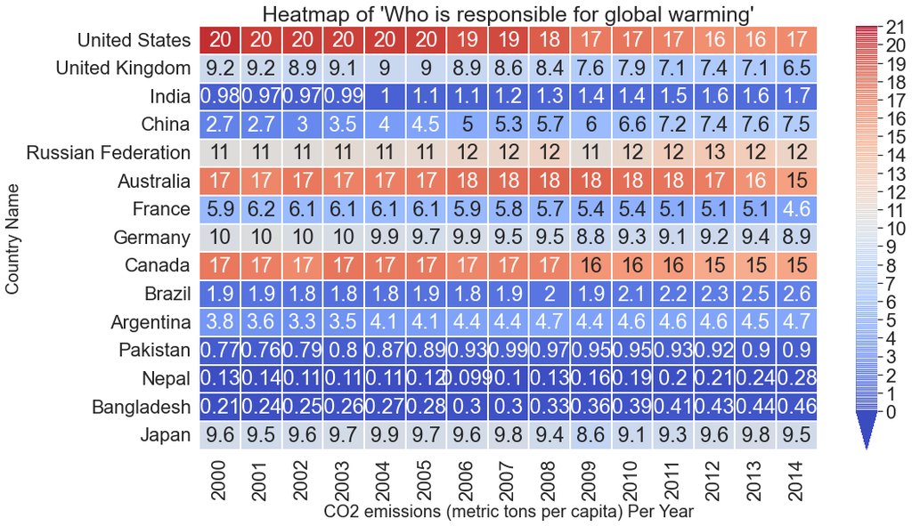

```python
# import libraries
import seaborn as sns # for data visualization
import matplotlib.pyplot as plt # for data visualization
import pandas as pd # for data analysis

# load dataset and create DataFrame ready to create heatmap
globalWarming_df = pd.read_csv("Who_is_responsible_for_global_warming.csv")
globalWarming_df = globalWarming_df.drop(columns=['Country Code', 'Indicator Name', 'Indicator Code'], axis=1).set_index('Country Name')

# set heatmap size
plt.figure(figsize= (16,9))

# create heatmap seaborn

cbar_kws = {"orientation":"vertical",
            "shrink":1,
            'extend':'min',
            'extendfrac':0.1,
            "ticks":np.arange(0,22),
            "drawedges":True,
           } # color bar keyword arguments

sns.heatmap(globalWarming_df, vmin = 0, vmax = 21, cmap="coolwarm", annot = True, linewidth = 2, cbar_kws=cbar_kws)

plt.title("Heatmap of 'Who is responsible for global warming'", fontsize = 25)
plt.xlabel("CO2 emissions (metric tons per capita) Per Year", fontsize = 20)
plt.ylabel("Country Name", fontsize = 20)
plt.show()
```

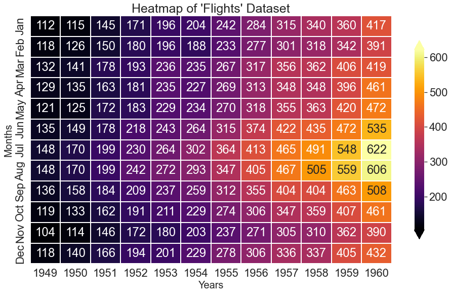

```python
# import libraries
import seaborn as sns # for data visualization
import matplotlib.pyplot as plt # for data visualization
import pandas as pd # for data analysis

# load dataset and create DataFrame ready to create heatmap
flights = sns.load_dataset("flights")
flights_df = flights.pivot("month", "year", "passengers")

# set heatmap size
plt.figure(figsize= (16,9))

# create heatmap seaborn

cbar_kws = {"shrink":.8,
           'extend':'both'}

sns.heatmap(flights_df, cmap="inferno", annot = True, fmt = 'd', linewidth = 2, cbar_kws=cbar_kws)

plt.title("Heatmap of 'Flights' Dataset", fontsize = 25)
plt.xlabel("Years", fontsize = 20)
plt.ylabel("Months", fontsize = 20)
plt.show()
```

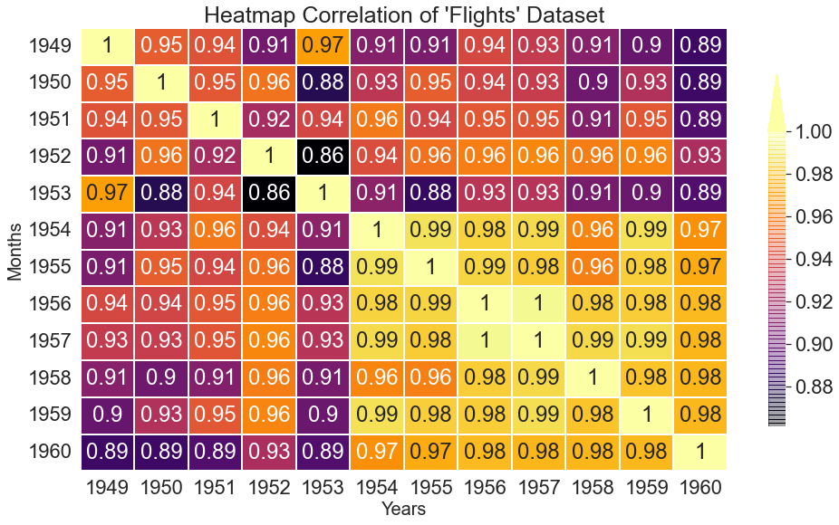

```python
# import libraries
import seaborn as sns # for data visualization
import matplotlib.pyplot as plt # for data visualization
import pandas as pd # for data analysis

# load dataset and create DataFrame ready to create heatmap
flights = sns.load_dataset("flights")
flights_df = flights.pivot("month", "year", "passengers")

# set heatmap size
plt.figure(figsize= (16,9))

# create heatmap seaborn

cbar_kws = {"shrink":.8,
           'extend':'max',
           'extendfrac':.2,
           "drawedges":True}

sns.heatmap(flights_df.corr(), cmap="inferno", annot = True, linewidth = 2, cbar_kws=cbar_kws)

plt.title("Heatmap Correlation of 'Flights' Dataset", fontsize = 25)
plt.xlabel("Years", fontsize = 20)
plt.ylabel("Months", fontsize = 20)
plt.show()
```